# Precursors

The input is DIA-NN’s precursor report: one row per precursor ion per run. limpa is built for this level. It reads the report, keeps confidently identified precursors, and later quantifies each protein from its precursors with a model of which ones go undetected. This step reads the report, picks one injection per biopsy, applies limpa’s two identity filters and saves the precursor matrix. Nothing is normalised and nothing is filtered on missing values; limpa models both.

## Packages

limpa supplies the reader and the filters, limma the `EList` they return and the density plot. `readDIANN()` reads Parquet through the nanoparquet package, which must be installed.

```r
library(here)
library(limma)
library(limpa)
library(dplyr)
library(ggplot2)
source(here("00_Setup", "Shared_functions", "workbooks.R"))
stopifnot(requireNamespace("nanoparquet", quietly = TRUE))
inputs <- c(
  report = "00_Setup/Input/report.parquet",
  metadata = "00_Setup/Input/metadata.csv"
)
paths <- vapply(inputs, here, character(1))
stopifnot(file.exists(paths))
out <- here("01_Processing", "01_Precursors", "c_data")
packageVersion("limpa")
```

```
[1] '1.4.2'
```

## Read the report

`readDIANN()` (limpa) reads the Parquet report into a precursor-by-run matrix of log2 `Precursor.Normalised` intensities, `NA` where a precursor was not detected in a run. It keeps a precursor in a run only when its q-values pass 0.01. Which q-values depends on the search: with match-between-runs (MBR), DIA-NN builds one library from all runs and searches each run against it, and limpa’s vignette then filters on `Q.Value`, `Lib.Q.Value` and `Lib.PG.Q.Value`. This report’s library q-values differ from its global ones, consistent with an MBR search, so the MBR set is used. (The no-MBR columns, `Global.Q.Value` and `Global.PG.Q.Value`, would keep 19,936 precursors against 22,389.)

```r
y <- readDIANN(
  paths[["report"]],
  q.columns = c("Q.Value", "Lib.Q.Value", "Lib.PG.Q.Value"), q.cutoffs = 0.01
)
c(precursors = nrow(y), runs = ncol(y), pct_missing = round(100 * mean(is.na(y$E)), 1))
```

```
 precursors        runs pct_missing
    22389.0        57.0        45.2
```

## One injection per biopsy

The report holds 57 runs from 18 people. Some biopsies were injected twice: the second injection carries a suffix (`r`, `rr`, `_4`, `_r`). Each run name gives the person and time point. The analysis keeps the 16 people in `metadata.csv` and, for each biopsy, the injection that detected the most precursors (decisions log, 2026-10-14).

```r
metadata <- readr::read_csv(paths[["metadata"]], show_col_types = FALSE)
run_map <- tibble(run = colnames(y), n_precursors = colSums(!is.na(y$E))) |>
  mutate(
    sample_id = sub("^JBBC_CL_(S\\d+)-(T\\d).*$", "\\1_\\2", run),
    injection = sub("^JBBC_CL_S\\d+-T\\d_?", "", run),
    in_study = sample_id %in% metadata$sample_id
  ) |>
  mutate(chosen = in_study & n_precursors == max(n_precursors), .by = sample_id) |>
  arrange(sample_id, desc(n_precursors))
stopifnot(
  !anyNA(run_map$sample_id), sum(run_map$chosen) == nrow(metadata),
  setequal(run_map$sample_id[run_map$chosen], metadata$sample_id)
)
print(run_map, n = Inf)
```

```
# A tibble: 57 × 6
   run              n_precursors sample_id injection in_study chosen
   <chr>                   <dbl> <chr>     <chr>     <lgl>    <lgl>
 1 JBBC_CL_S03-T1          10875 S03_T1    ""        TRUE     TRUE
 2 JBBC_CL_S03-T2          13066 S03_T2    ""        TRUE     TRUE
 3 JBBC_CL_S03-T3          14861 S03_T3    ""        TRUE     TRUE
 4 JBBC_CL_S04-T1r         14665 S04_T1    "r"       TRUE     TRUE
 5 JBBC_CL_S04-T2          16656 S04_T2    ""        TRUE     TRUE
 6 JBBC_CL_S04-T3          13762 S04_T3    ""        TRUE     TRUE
 7 JBBC_CL_S05-T1          15037 S05_T1    ""        TRUE     TRUE
 8 JBBC_CL_S05-T2          15641 S05_T2    ""        TRUE     TRUE
 9 JBBC_CL_S05-T3          11783 S05_T3    ""        TRUE     TRUE
10 JBBC_CL_S06-T1          10204 S06_T1    ""        TRUE     TRUE
11 JBBC_CL_S06-T2          14920 S06_T2    ""        TRUE     TRUE
12 JBBC_CL_S06-T3          14715 S06_T3    ""        TRUE     TRUE
```

[output cut: 45 more lines]

Biopsies with more than one injection, and the one kept:

```r
filter(run_map, n() > 1, .by = sample_id)
```

```
# A tibble: 8 × 6
  run              n_precursors sample_id injection in_study chosen
  <chr>                   <dbl> <chr>     <chr>     <lgl>    <lgl>
1 JBBC_CL_S07-T1_4        14576 S07_T1    "4"       FALSE    FALSE
2 JBBC_CL_S07-T1          11819 S07_T1    ""        FALSE    FALSE
3 JBBC_CL_S13-T1_4          361 S13_T1    "4"       FALSE    FALSE
4 JBBC_CL_S13-T1            255 S13_T1    ""        FALSE    FALSE
5 JBBC_CL_S17-T1_4        10886 S17_T1    "4"       TRUE     TRUE
6 JBBC_CL_S17-T1          10162 S17_T1    ""        TRUE     FALSE
7 JBBC_CL_S29-T1_4        12605 S29_T1    "4"       TRUE     TRUE
8 JBBC_CL_S29-T1           8551 S29_T1    ""        TRUE     FALSE
```

## Keep the chosen runs

The chosen runs are renamed to their `sample_id` and matched to `metadata.csv`. A precursor detected only in dropped runs must go: left in, it looks undetected in all 48 biopsies, which shifts the detection curve and pulls its protein’s values down (tested: values moved by up to 5 log2 units). limpa’s `removeNARows()` does this, but with the installed limpa and limma it fails inside limma’s `EList` subsetting (`y[keep, , ]` passes an empty argument), so plain subsetting does it.

```r
chosen <- filter(run_map, chosen)
y <- y[, chosen$run]
colnames(y) <- chosen$sample_id
y$targets <- metadata[match(colnames(y), metadata$sample_id), ]
y <- y[rowSums(!is.na(y$E)) > 0, ]
stopifnot(identical(y$targets$sample_id, colnames(y)))
c(precursors = nrow(y), proteins = n_distinct(y$genes$Protein.Group), runs = ncol(y))
```

```
precursors   proteins       runs
     22342       2401         48
```

## Identity filters

limpa’s vignette applies two optional filters for easier interpretation: `filterNonProteotypicPeptides()` drops precursors whose peptide maps to more than one protein, and `filterCompoundProteins()` drops protein groups that name two or more proteins. Neither looks at intensity or missing values.

```r
before <- c(precursors = nrow(y), proteins = n_distinct(y$genes$Protein.Group))
y <- filterNonProteotypicPeptides(y)
y <- filterCompoundProteins(y)
after <- c(precursors = nrow(y), proteins = n_distinct(y$genes$Protein.Group))
filter_log <- tibble(count = names(before), before, after)
filter_log
```

```
# A tibble: 2 × 3
  count      before after
  <chr>       <int> <int>
1 precursors  22342 22342
2 proteins     2401  2401
```

Both filters remove nothing here: DIA-NN already reported proteotypic precursors only and no protein group names two proteins. They stay as a check.

## Detection per run

Precursors and proteins detected in each kept run. limpa keeps weak runs; the comparisons down-weight them through sample weights rather than dropping them.

```r
per_run <- tibble(
  sample_id = colnames(y),
  n_precursors = colSums(!is.na(y$E)),
  n_proteins = colSums(rowsum(1 * !is.na(y$E), y$genes$Protein.Group) > 0)
) |>
  left_join(select(metadata, sample_id, group, timepoint), by = "sample_id") |>
  arrange(n_precursors)
print(per_run, n = 6)
```

```
# A tibble: 48 × 5
  sample_id n_precursors n_proteins group timepoint
  <chr>            <dbl>      <dbl> <chr> <chr>
1 S28_T3            4048        810 HR    T3
2 S28_T2            6699       1061 HR    T2
3 S10_T2            8305       1490 HR    T2
4 S06_T1           10204       1597 LR    T1
5 S03_T1           10875       1521 HR    T1
6 S17_T1           10886       1717 LR    T1
# ℹ 42 more rows
```

```r
summary(per_run$n_precursors)
```

```
   Min. 1st Qu.  Median    Mean 3rd Qu.    Max.
   4048   12039   13102   12951   14586   16656
```

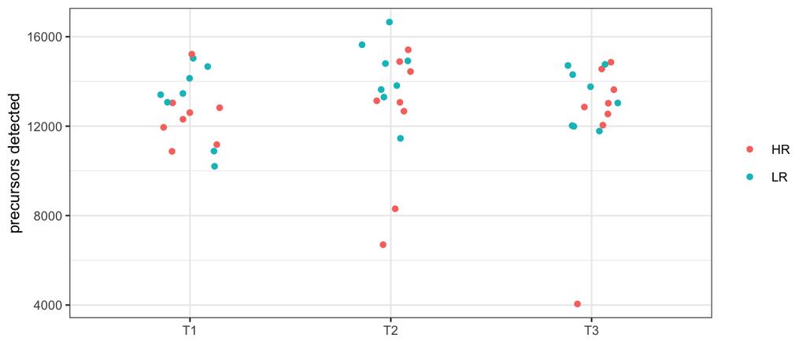

Figure 1: Precursors detected per kept run, by time point and group.

```r
ggplot(per_run, aes(timepoint, n_precursors, colour = group)) +
  geom_point(position = position_jitter(width = 0.15, seed = 1)) +
  labs(x = NULL, y = "precursors detected", colour = NULL) +
  theme_bw(base_size = 10)
```

## Intensities per biopsy

limpa adds no normalisation: it uses DIA-NN’s `Precursor.Normalised`. If that worked, every biopsy’s distribution of detected log2 intensities sits in the same place. limma’s `plotDensities()` draws one curve per biopsy; a shifted curve would mean the normalisation failed for that run. Thin runs detect fewer faint precursors, so their curves start further right.

```
   Min. 1st Qu.  Median    Mean 3rd Qu.    Max.
  19.90   20.21   20.47   20.60   20.71   24.11
```

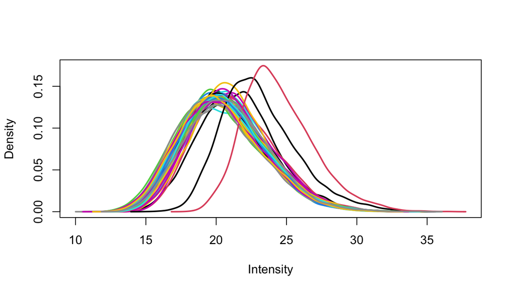

Figure 2: Detected log2 precursor intensity per biopsy (limma’s plotDensities).

```r
plotDensities(y, legend = FALSE, main = "")
round(summary(apply(y$E, 2, median, na.rm = TRUE)), 2)
```

## Validation

```r
stopifnot(
  ncol(y) == 48, !anyDuplicated(colnames(y)), all(rowSums(!is.na(y$E)) > 0),
  !anyNA(y$genes$Protein.Group)
)
```

## Summary

22342 precursors from 2401 proteins in 48 biopsies; 42% of the matrix is missing, and limpa models every missing value in the next step.

## Save

```r
dir.create(out, showWarnings = FALSE)
saveRDS(y, file.path(out, "precursors.rds"))
readr::write_csv(run_map, file.path(out, "run_map.csv"))
write_workbook(
  list(run_map = run_map, filter_log = filter_log, per_run = per_run),
  c(
    "Every run in the report: biopsy, injection, precursors detected, and whether it was kept.",
    "Precursors and proteins before and after the identity filters.",
    "Precursors and proteins detected in each kept run."
  ),
  file.path(out, "precursors.xlsx"), inputs, paths
)
```